# Backpropagation: From Theory to Practice

**The Algorithm That Powers Modern AI**

> *"Backpropagation is not just an algorithm—it's the mathematical bridge between human intuition and machine learning."*

## 🎯 Learning Objectives

By completing this comprehensive guide, you will:

## 📋 Complete Roadmap

### 🔍 **PART I: Foundations** *(Theory & Mathematics)*

| Section | Focus | Key Skills |
| --- | --- | --- |
| **1. Introduction** | Why backprop matters | Historical context, motivation |
| **2. Network Architecture** | Visual understanding | Diagram interpretation, notation |
| **3. Mathematical Derivation** | Chain rule mastery | Gradient computation, error propagation |
| **4. Algorithm Steps** | Process breakdown | Forward/backward pass coordination |

### 💻 **PART II: Implementation** *(Hands-on Coding)*

[output not shown]

### 🚀 **PART III: Modern Frameworks** *(Professional Practice)*

| Section | Focus | Key Skills |
| --- | --- | --- |
| **8. PyTorch Mastery** | Research-grade code | Automatic differentiation, flexibility |
| **9. Hugging Face Integration** | NLP applications | Transformer training, tokenization |
| **10. TensorFlow Production** | Scalable deployment | Keras API, distributed training |
| **11. Framework Comparison** | Tool selection | When to use what, trade-offs |

## 🚀 Why Backpropagation is Revolutionary

> *"Before backprop, training neural networks was like navigating in the dark. After backprop, we had a GPS for the landscape of learning."*

### 🌟 The Historical Context

**The Problem (Pre-1986)**:

- Neural networks existed but couldn't learn complex patterns
- No efficient way to train multi-layer networks
- The "XOR problem" seemed unsolvable
- AI winter was looming due to these limitations

**The Breakthrough**: Backpropagation, popularized by Rumelhart, Hinton, and Williams in 1986, solved the credit assignment problem: *How do we know which weights to blame for errors?*

### 🎯 The Core Insight

**The Genius of Backpropagation**:

1. **🔄 Error Attribution**: Systematically assigns blame to each parameter
2. **⚡ Efficient Computation**: Updates all weights in one backward pass
3. **🌊 Gradient Flow**: Uses calculus (chain rule) to propagate error signals
4. **🎯 Universal Learning**: Works for any differentiable function

### 💪 What Backpropagation Enables

| **Capability** | **Impact** | **Examples** |
| --- | --- | --- |
| **Deep Learning** | Multi-layer training | ResNet, Transformers, CNNs |
| **End-to-End Learning** | Direct optimization | Image→Caption, Speech→Text |
| **Gradient-Based Optimization** | Principled updates | Adam, SGD, RMSprop |
| **Automatic Differentiation** | Framework automation | PyTorch, TensorFlow |

### 🔧 The Engineering Marvel

**Modern Backprop is More Than Math**:

- **🚀 Computational Graphs**: Automatic differentiation frameworks
- **💾 Memory Optimization**: Gradient checkpointing, mixed precision
- **⚡ Parallelization**: Distributed training across GPUs/TPUs
- **🎛️ Adaptive Methods**: Smart learning rate adjustment

### 🧩 The Learning Journey Ahead

**Progressive Understanding**:

1. **📐 Mathematics**: Start with the elegant theory
2. **🔬 Implementation**: Build intuition through coding
3. **🛠️ Tools**: Master modern frameworks
4. **🎯 Application**: Solve real problems

**Key Questions We'll Answer**:

- 🤔 How does a network "know" which weights caused the error?
- 🔍 Why does the chain rule make everything possible?
- ⚡ How do modern frameworks automate the hard parts?
- 🎯 When should you implement vs. use existing tools?

### 🌊 The Ripple Effect

Backpropagation didn't just solve one problem—it **launched the AI revolution**:

- **1990s**: Neural networks became practical
- **2000s**: Support Vector Machines dominated (temporarily)
- **2010s**: Deep learning renaissance began
- **2020s**: Transformers and foundation models
- **Today**: GPT, BERT, Stable Diffusion, and beyond

**🎓 Your Mission**: Master the algorithm that made it all possible!

*Ready to dive deep? Let's start with the visual architecture...* 👇

# 🔍 Part I: Theory & Mathematics

*Understanding the mathematical foundation of neural network training*

## 🎨 Network Architecture Visualization

> *"A picture is worth a thousand equations—and understanding this diagram unlocks backpropagation's secrets."*

### 🔍 Reading the Diagram

The diagram below shows a **3-layer neural network** (input → hidden → output) with **complete backpropagation flows**. Each element has a specific meaning:

### 📊 **Node Types & Their Meanings**

| **Symbol** | **Color** | **Purpose** | **Mathematical Role** |
| --- | --- | --- | --- |
| **$x_j$** | Black | Input features | Original data: $x_1, x_2, x_3$ |
| **$h_j$** | Blue | Hidden activations | First transformation: $h_j = f(z_j^{(1)})$ |
| **$y_j$** | Black | Network outputs | Final predictions: $y_j = f(z_j^{(2)})$ |
| **$d_j$** | Red | Target values | Ground truth labels |
| **$\delta_j^{(l)}$** | Blue boxes | **Error gradients** | **Heart of backprop!** |

### 🔄 **Information Flow Directions**

**🔴 Forward Pass (Black Arrows)**:

```
Input → Linear → Activation → Linear → Activation → Output
x ──→ z^(1) ──→ h ──→ z^(2) ──→ y
```

**🔵 Backward Pass (Blue Arrows)**:

```
Error ← Gradient ← Chain Rule ← Gradient ← Chain Rule
δ^(2) ←── δ^(1) ←── δ^(0)
```

### ⚡ **The Magic of Delta (δ) Terms**

**🎯 Key Insight**: The $\delta$ values are the **"error messengers"**—they carry information about how much each neuron contributed to the final error.

**Delta Definitions**:

- **$\delta^{(2)}_j$**: "How much did output neuron $j$ contribute to the error?"
  - $\delta^{(2)}_j = (y_j - d_j) \cdot f'(z_j^{(2)})$
- **$\delta^{(1)}_j$**: "How much did hidden neuron $j$ contribute to the error?"
  - $\delta^{(1)}_j = \left(\sum_k \delta^{(2)}_k w_{kj}^{(2)}\right) \cdot f'(z_j^{(1)})$

### 🔗 **Weight Update Formula**

The beautiful simplicity of backprop: $$\boxed{\Delta w_{ji}^{(l)} = -\eta \cdot \delta_j^{(l)} \cdot o_i^{(l-1)}}$$

**Interpretation**:

- $\delta_j^{(l)}$: "How much neuron $j$ is to blame for the error"
- $o_i^{(l-1)}$: "How much input $i$ influenced neuron $j$"
- $\eta$: "How big steps to take" (learning rate)

### 🎭 **Bias Terms: The Hidden Players**

**Special Connections**: Notice the "+1" nodes (bias units)

- Always output +1 (constant input)
- Connected with dashed lines
- Updated using same delta values: $\Delta b_j^{(l)} = -\eta \delta_j^{(l)}$

### 🧮 **Mathematical Operations at Each Layer**

**Linear Transformation**: $$z_j^{(l)} = \sum_{i} w_{ji}^{(l)} \cdot o_i^{(l-1)} + b_j^{(l)}$$

**Activation Function**: $$o_j^{(l)} = f(z_j^{(l)}) \quad \text{(typically sigmoid, ReLU, tanh)}$$

**Error Computation**: $$E = \frac{1}{2}\sum_j (d_j - y_j)^2 \quad \text{(Mean Squared Error)}$$

### 🎯 **The Chain Rule in Action**

The genius of backprop is applying the **chain rule systematically**:

$$\frac{\partial E}{\partial w_{ji}^{(l)}} = \frac{\partial E}{\partial z_j^{(l)}} \cdot \frac{\partial z_j^{(l)}}{\partial w_{ji}^{(l)}} = \delta_j^{(l)} \cdot o_i^{(l-1)}$$

**🔥 This is why we compute deltas first, then use them for all weight updates!**

**💡 Pro Tip**: Study this diagram until you can trace both forward and backward passes mentally. It's the roadmap for everything that follows!

[figure not shown]

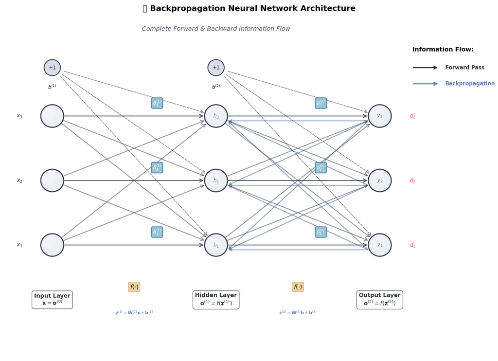

```
🎨 Enhanced Network Diagram Generated!
📊 Key Visual Features:
   • Color-coded information flows
   • Delta terms highlighted as the core of backprop
   • Mathematical notation clearly labeled
   • Professional styling for better comprehension
```

```python
import matplotlib.pyplot as plt
import numpy as np
import matplotlib.patches as patches
from matplotlib.patches import FancyBboxPatch, ConnectionPatch, FancyArrowPatch

# Set up the figure with better styling
plt.style.use('default')  # Ensure consistent styling
fig, ax = plt.subplots(1, 1, figsize=(16, 12))
ax.set_xlim(-1.5, 12)
ax.set_ylim(-1, 10)
ax.axis('off')

# Define positions for neurons (better spacing)
input_layer = [(0, y) for y in [2.5, 4.5, 6.5]]
hidden_layer = [(5, y) for y in [2.5, 4.5, 6.5]]
output_layer = [(10, y) for y in [2.5, 4.5, 6.5]]

# Enhanced color scheme
forward_color = '#2E3440'  # Dark blue-gray
backward_color = '#5E81AC'  # Professional blue
neuron_color = '#ECEFF4'  # Light gray
neuron_edge = '#3B4252'  # Dark gray
bias_color = '#D8DEE9'  # Lighter gray
delta_color = '#88C0D0'  # Light blue
target_color = '#BF616A'  # Red
activation_color = '#EBCB8B'  # Yellow

# Enhanced neuron styling
neuron_radius = 0.35
bias_radius = 0.25

# Draw main neurons with better styling
layer_info = [
    ('Input', input_layer, neuron_color),
    ('Hidden', hidden_layer, neuron_color),
    ('Output', output_layer, neuron_color)
]

for layer_name, positions, color in layer_info:
    for i, (x, y) in enumerate(positions):
        # Main neuron circle
        circle = patches.Circle((x, y), neuron_radius,
                              facecolor=color, edgecolor=neuron_edge,
                              linewidth=2.5, zorder=3)
        ax.add_patch(circle)

        # Add subtle inner highlight
        inner_circle = patches.Circle((x-0.08, y+0.08), neuron_radius*0.6,
                                    facecolor='white', alpha=0.3, zorder=4)
        ax.add_patch(inner_circle)

# Draw bias nodes with enhanced styling
bias_positions = [(0, 8), (5, 8)]
bias_labels = ['$+1$', '$+1$']

for i, ((bx, by), label) in enumerate(zip(bias_positions, bias_labels)):
    # Bias circle
    circle = patches.Circle((bx, by), bias_radius,
                          facecolor=bias_color, edgecolor=neuron_edge,
                          linewidth=2, zorder=3)
    ax.add_patch(circle)

    # Bias label
    ax.text(bx, by, label, ha='center', va='center',
           fontweight='bold', fontsize=11, zorder=5)

# Draw forward connections with varying opacity for clarity
def draw_connection(start, end, color, style='-', alpha=1.0, linewidth=2):
    """Draw connection between neurons"""
    x1, y1 = start
    x2, y2 = end

    # Calculate connection points on circle edges
    dx, dy = x2 - x1, y2 - y1
    length = np.sqrt(dx**2 + dy**2)

    start_x = x1 + (dx/length) * neuron_radius
    start_y = y1 + (dy/length) * neuron_radius
    end_x = x2 - (dx/length) * neuron_radius
    end_y = y2 - (dy/length) * neuron_radius

    arrow = FancyArrowPatch((start_x, start_y), (end_x, end_y),
                           arrowstyle='->', mutation_scale=18,
                           color=color, linewidth=linewidth,
                           linestyle=style, alpha=alpha, zorder=2)
    ax.add_patch(arrow)

# Forward connections (input to hidden)
for i, (x1, y1) in enumerate(input_layer):
    for j, (x2, y2) in enumerate(hidden_layer):
        alpha = 0.8 if i == j else 0.5  # Highlight direct connections
        draw_connection((x1, y1), (x2, y2), forward_color, alpha=alpha)

# Forward connections (hidden to output)
for i, (x1, y1) in enumerate(hidden_layer):
    for j, (x2, y2) in enumerate(output_layer):
        alpha = 0.8 if i == j else 0.5
        draw_connection((x1, y1), (x2, y2), forward_color, alpha=alpha)

# Bias connections with dashed style
for bx, by in bias_positions:
    target_layer = hidden_layer if bx < 3 else output_layer
    for hx, hy in target_layer:
        draw_connection((bx, by), (hx, hy), forward_color,
                       style='--', alpha=0.6, linewidth=1.5)

# Backward connections (more subtle)
for i, (x2, y2) in enumerate(output_layer):
    for j, (x1, y1) in enumerate(hidden_layer):
        # Offset backward arrows slightly
        start_pos = (x2 - neuron_radius, y2 - 0.15)
        end_pos = (x1 + neuron_radius, y1 - 0.15)

        arrow = FancyArrowPatch(start_pos, end_pos,
                               arrowstyle='->', mutation_scale=14,
                               color=backward_color, linewidth=2,
                               alpha=0.7, zorder=1)
        ax.add_patch(arrow)

# Enhanced layer labels
layer_data = [
    (0, 'Input Layer\n$\\mathbf{x} = \\mathbf{o}^{(0)}$', forward_color),
    (5, 'Hidden Layer\n$\\mathbf{o}^{(1)} = f(\\mathbf{z}^{(1)})$', forward_color),
    (10, 'Output Layer\n$\\mathbf{o}^{(2)} = f(\\mathbf{z}^{(2)})$', forward_color)
]

for x, label, color in layer_data:
    ax.text(x, 0.8, label, ha='center', va='center',
           fontsize=13, fontweight='bold', color=color,
           bbox=dict(boxstyle='round,pad=0.4', facecolor='white',
                    edgecolor=color, alpha=0.9))

# Enhanced neuron labels
neuron_labels = [
    (input_layer, ['$x_1$', '$x_2$', '$x_3$'], -1.0, forward_color),
    (hidden_layer, ['$h_1$', '$h_2$', '$h_3$'], 0, '#4C566A'),
    (output_layer, ['$y_1$', '$y_2$', '$y_3$'], 0, forward_color)
]

for positions, labels, x_offset, color in neuron_labels:
    for (x, y), label in zip(positions, labels):
        ax.text(x + x_offset, y, label, ha='center', va='center',
               fontsize=12, fontweight='bold', color=color)

# Target labels (red)
for i, (x, y) in enumerate(output_layer):
    ax.text(x + 1.0, y, f'$d_{i+1}$', ha='center', va='center',
           fontsize=12, fontweight='bold', color=target_color)

# DELTA labels - the key innovation!
delta_style = dict(boxstyle='round,pad=0.3', facecolor=delta_color,
                  edgecolor=backward_color, alpha=0.9, linewidth=2)

# Output deltas
for i, (x, y) in enumerate(output_layer):
    ax.text(x - 1.8, y + 0.4, f'$\\delta^{{(2)}}_{i+1}$',
           ha='center', va='center', fontsize=11,
           fontweight='bold', color='white', bbox=delta_style)

# Hidden deltas
for i, (x, y) in enumerate(hidden_layer):
    ax.text(x - 1.8, y + 0.4, f'$\\delta^{{(1)}}_{i+1}$',
           ha='center', va='center', fontsize=11,
           fontweight='bold', color='white', bbox=delta_style)

# Bias labels
ax.text(0, 7.4, '$b^{(1)}$', ha='center', va='center',
       fontsize=11, fontweight='bold')
ax.text(5, 7.4, '$b^{(2)}$', ha='center', va='center',
       fontsize=11, fontweight='bold')

# Enhanced legend with better positioning
legend_x, legend_y = 11, 8.5
ax.text(legend_x, legend_y, 'Information Flow:',
       fontsize=14, fontweight='bold', ha='left')

# Forward arrow legend
arrow1 = FancyArrowPatch((legend_x, legend_y - 0.5), (legend_x + 0.8, legend_y - 0.5),
                        arrowstyle='->', mutation_scale=16,
                        color=forward_color, linewidth=2.5)
ax.add_patch(arrow1)
ax.text(legend_x + 1.0, legend_y - 0.5, 'Forward Pass',
       fontsize=12, fontweight='bold', color=forward_color, va='center')

# Backward arrow legend
arrow2 = FancyArrowPatch((legend_x, legend_y - 1.0), (legend_x + 0.8, legend_y - 1.0),
                        arrowstyle='->', mutation_scale=16,
                        color=backward_color, linewidth=2.5)
ax.add_patch(arrow2)
ax.text(legend_x + 1.0, legend_y - 1.0, 'Backpropagation',
       fontsize=12, fontweight='bold', color=backward_color, va='center')

# Activation function indicators
activation_style = dict(boxstyle='round,pad=0.3', facecolor=activation_color,
                       alpha=0.8, edgecolor='#D08770')

ax.text(2.5, 1.2, '$f(\\cdot)$', ha='center', va='center',
       fontsize=13, fontweight='bold', bbox=activation_style)
ax.text(7.5, 1.2, '$f(\\cdot)$', ha='center', va='center',
       fontsize=13, fontweight='bold', bbox=activation_style)

# Add mathematical flow indicators
ax.text(2.5, 0.4, '$\\mathbf{z}^{(1)} = \\mathbf{W}^{(1)}\\mathbf{x} + \\mathbf{b}^{(1)}$',
       ha='center', va='center', fontsize=10, style='italic', color='#5E81AC')
ax.text(7.5, 0.4, '$\\mathbf{z}^{(2)} = \\mathbf{W}^{(2)}\\mathbf{h} + \\mathbf{b}^{(2)}$',
       ha='center', va='center', fontsize=10, style='italic', color='#5E81AC')

# Enhanced title
plt.suptitle('🧠 Backpropagation Neural Network Architecture',
            fontsize=18, fontweight='bold', y=0.95)

# Add subtitle
ax.text(5, 9.2, 'Complete Forward & Backward Information Flow',
       ha='center', va='center', fontsize=14, style='italic', color='#4C566A')

plt.tight_layout()
plt.show()

print("🎨 Enhanced Network Diagram Generated!")
print("📊 Key Visual Features:")
print("   • Color-coded information flows")
print("   • Delta terms highlighted as the core of backprop")
print("   • Mathematical notation clearly labeled")
print("   • Professional styling for better comprehension")
```

## 📐 Mathematical Foundation

> *"Mathematics is the language of backpropagation—let's speak it fluently."*

### 🏗️ **Network Architecture Setup**

**Notation Convention** (Critical for Understanding):

| **Symbol** | **Meaning** | **Example** | **Dimension** |
| --- | --- | --- | --- |
| $l$ | Layer index | $l \in \{0, 1, 2\}$ | - |
| $j$ | Neuron index in layer $l$ | $j \in \{1, 2, 3\}$ | - |
| $i$ | Input index to neuron $j$ | $i \in \{1, 2, 3\}$ | - |
| $z_j^{(l)}$ | **Pre-activation** (linear output) | $z_1^{(1)} = w_{11}^{(1)}x_1 + w_{12}^{(1)}x_2 + b_1^{(1)}$ | Scalar |
| $o_j^{(l)}$ | **Post-activation** (neuron output) | $o_1^{(1)} = \sigma(z_1^{(1)})$ | Scalar |
| $w_{ji}^{(l)}$ | Weight from neuron $i$ (layer $l-1$) to $j$ (layer $l$) | $w_{21}^{(2)}$: hidden neuron 1 → output neuron 2 | Scalar |
| $b_j^{(l)}$ | Bias for neuron $j$ in layer $l$ | $b_2^{(1)}$: bias for 2nd hidden neuron | Scalar |

### 🎯 **The Goal: Minimize Loss**

**Mean Squared Error** (most common for regression): $$\boxed{E = \frac{1}{2}\sum_{j=1}^{n_L} (d_j - o_j^{(L)})^2}$$

Where $d_j$ is target output and $o_j^{(L)}$ is actual output.

We use **gradient descent** to find optimal weights: $$w_{ji}^{(l)} \leftarrow w_{ji}^{(l)} - \eta \frac{\partial E}{\partial w_{ji}^{(l)}}$$

**🔥 The Challenge**: How do we compute $\frac{\partial E}{\partial w_{ji}^{(l)}}$ efficiently?

**🎉 The Solution**: Backpropagation algorithm!

## ⚡ Backpropagation Equations: The Heart of Learning

> *"These equations are where magic happens—transforming errors into wisdom."*

### 🎯 **The Strategy: Work Backwards**

**Key Insight**: Start from the output (where we know the error) and propagate gradients backward through each layer using the **chain rule**.

### 🔥 **Output Layer (Layer 2): Where It All Begins**

**🎪 The Setup**: We know the error at the output, so gradients are straightforward.

**Weight Gradient via Chain Rule**: $$\frac{\partial E}{\partial w_{ji}^{(2)}} = \frac{\partial E}{\partial o_j^{(2)}} \cdot \frac{\partial o_j^{(2)}}{\partial z_j^{(2)}} \cdot \frac{\partial z_j^{(2)}}{\partial w_{ji}^{(2)}}$$

**Let's Compute Each Term**:

1️⃣ **Error w.r.t. Output**: $$\frac{\partial E}{\partial o_j^{(2)}} = \frac{\partial}{\partial o_j^{(2)}}\left[\frac{1}{2}(d_j - o_j^{(2)})^2\right] = -(d_j - o_j^{(2)})$$

2️⃣ **Output w.r.t. Pre-activation**: $$\frac{\partial o_j^{(2)}}{\partial z_j^{(2)}} = f'(z_j^{(2)})$$

3️⃣ **Pre-activation w.r.t. Weight**: $$\frac{\partial z_j^{(2)}}{\partial w_{ji}^{(2)}} = \frac{\partial}{\partial w_{ji}^{(2)}}\left[\sum_k w_{jk}^{(2)} o_k^{(1)} + b_j^{(2)}\right] = o_i^{(1)}$$

### 🌟 **The Output Delta Definition**

**Combining the terms**: $$\boxed{\delta_j^{(2)} \triangleq \frac{\partial E}{\partial z_j^{(2)}} = -(d_j - o_j^{(2)}) \cdot f'(z_j^{(2)})}$$

**Physical Interpretation**:

- $\delta_j^{(2)}$ = "How much does a small change in $z_j^{(2)}$ affect the total error?"
- Combines **error magnitude** $(d_j - o_j^{(2)})$ with **activation sensitivity** $f'(z_j^{(2)})$

### ✨ **Weight Updates**

**For Output Layer**: $$\boxed{w_{ji}^{(2)} \leftarrow w_{ji}^{(2)} - \eta \delta_j^{(2)} o_i^{(1)}}$$

**For Hidden Layer**: $$\delta_j^{(1)} = \left(\sum_k \delta_k^{(2)}w_{kj}^{(2)}\right) f'(z_j^{(1)})$$ $$\boxed{w_{ji}^{(1)} \leftarrow w_{ji}^{(1)} - \eta \delta_j^{(1)} o_i^{(0)}}$$

### � **Bias Updates**

**For Output Layer**: $$\boxed{b_j^{(2)} \leftarrow b_j^{(2)} - \eta \delta_j^{(2)}}$$

**For Hidden Layer**: $$\boxed{b_j^{(1)} \leftarrow b_j^{(1)} - \eta \delta_j^{(1)}}$$

**💡 Pattern**: Bias updates use the same delta values but without any input multiplication!

## 🌟 Universal Backpropagation Algorithm

> *"From 3 layers to 300 layers—the same elegant pattern scales infinitely."*

### 🚀 **The General Formulation**

**For Any Network with $L$ Layers** (where $l = 1, 2, \ldots, L$):

### 📋 **Algorithm Steps**

**🔄 Step 1: Forward Pass**

```
For l = 1 to L:
    z^(l) = W^(l) × o^(l-1) + b^(l)
    o^(l) = f(z^(l))
```

**🔙 Step 2: Backward Pass**

```
# Output layer (l = L)
δ^(L) = -(d - o^(L)) ⊙ f'(z^(L))

# Hidden layers (l = L-1, L-2, ..., 1)
For l = L-1 down to 1:
    δ^(l) = (W^(l+1))^T × δ^(l+1) ⊙ f'(z^(l))
```

**⚡ Step 3: Parameter Updates**

```
For l = 1 to L:
    W^(l) ← W^(l) - η × δ^(l) × (o^(l-1))^T
    b^(l) ← b^(l) - η × δ^(l)
```

### 🎯 **Key Observations**

**🔥 Pattern Recognition**:

1. **Output Layer**: Error comes from comparing with targets
2. **Hidden Layers**: Error comes from the layer above via weighted sum
3. **All Layers**: Use the same update rule once deltas are computed

**⚡ Matrix Notation**:

- $\mathbf{W}^{(l)} \in \mathbb{R}^{n_l \times n_{l-1}}$: Weight matrix for layer $l$
- $\mathbf{b}^{(l)} \in \mathbb{R}^{n_l}$: Bias vector for layer $l$
- $\boldsymbol{\delta}^{(l)} \in \mathbb{R}^{n_l}$: Error gradient vector for layer $l$
- $\odot$: Element-wise multiplication (Hadamard product)

### 🧮 **The Universal Delta Formula**

**For Layer $l$ (where $l < L$)**: $$\boxed{\boldsymbol{\delta}^{(l)} = \left(\mathbf{W}^{(l+1)}\right)^T \boldsymbol{\delta}^{(l+1)} \odot f'(\mathbf{z}^{(l)})}$$

**Interpretation**:

- $\left(\mathbf{W}^{(l+1)}\right)^T \boldsymbol{\delta}^{(l+1)}$: "Pull back" errors from next layer
- $f'(\mathbf{z}^{(l)})$: Weight by activation sensitivity
- $\odot$: Element-wise scaling for each neuron

### 🎪 **Why This Works for Any Depth**

**🔗 Chain Rule Recursion**: $$\frac{\partial E}{\partial z_j^{(l)}} = \sum_{k} \frac{\partial E}{\partial z_k^{(l+1)}} \cdot \frac{\partial z_k^{(l+1)}}{\partial o_j^{(l)}} \cdot \frac{\partial o_j^{(l)}}{\partial z_j^{(l)}}$$

**🎯 This recursive structure allows**:

- Networks with hundreds of layers (ResNet, Transformers)
- Different activation functions per layer
- Skip connections and complex architectures

### 💻 **Computational Efficiency**

**Time Complexity**: $O(W)$ where $W$ is total number of weights

- **Forward pass**: One matrix multiplication per layer
- **Backward pass**: One matrix multiplication per layer
- **Updates**: Element-wise operations

**Space Complexity**: $O(N)$ where $N$ is total number of neurons

- Must store activations for backward pass
- Modern frameworks use techniques like gradient checkpointing

### 🛠️ **Implementation Considerations**

**🔧 Practical Details**:

1. **Activation Storage**: Save $o^{(l)}$ and $z^{(l)}$ during forward pass
2. **Gradient Accumulation**: Can batch multiple examples
3. **Numerical Stability**: Watch out for vanishing/exploding gradients
4. **Memory Management**: Clear activations when no longer needed

**⚡ Modern Optimizations**:

- **Automatic Differentiation**: Frameworks handle the chain rule
- **Mixed Precision**: Use float16 for speed, float32 for accuracy
- **Gradient Checkpointing**: Trade computation for memory
- **Distributed Training**: Parallelize across multiple devices

### 🎯 **The Big Picture**

**🌟 Universal Truth**: Whether you're training:

- A simple 3-layer network for XOR
- ResNet-152 for ImageNet
- GPT-3 with 175 billion parameters
- Your custom architecture

**The same backpropagation principle applies**:

1. Forward pass computes predictions
2. Backward pass computes gradients
3. Parameters update toward better solutions

**🚀 That's the power of backpropagation—it scales from toy problems to powering the AI revolution!**

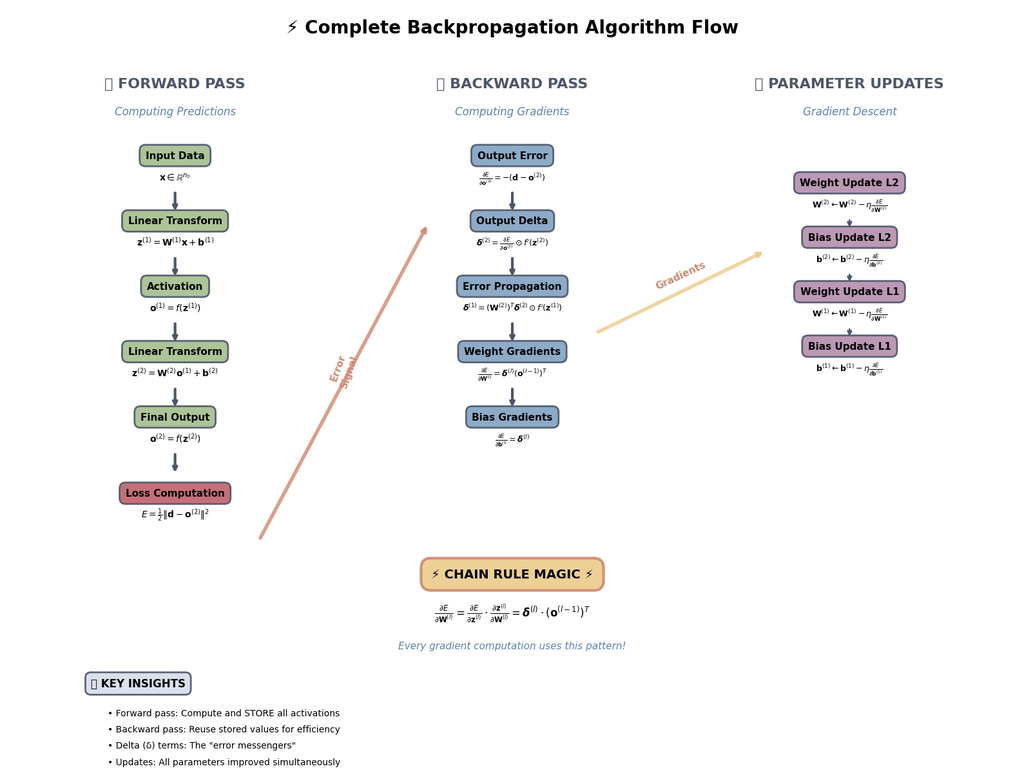

```
🎯 Enhanced Algorithm Flow Diagram Complete!
📚 Visual Learning Features:
   • Color-coded phases for easy understanding
   • Mathematical formulas with clear context
   • Cross-phase arrows showing information flow
   • Chain rule emphasis as the core principle
   • Key insights for practical understanding
```

```python
# Create an enhanced mathematical flow diagram for backpropagation
fig, ax = plt.subplots(1, 1, figsize=(16, 12))
ax.set_xlim(0, 12)
ax.set_ylim(0, 13)
ax.axis('off')

# Enhanced styling
forward_style = dict(boxstyle='round,pad=0.6', facecolor='#A3BE8C',
                    alpha=0.9, edgecolor='#4C566A', linewidth=2)
backward_style = dict(boxstyle='round,pad=0.6', facecolor='#81A1C1',
                     alpha=0.9, edgecolor='#4C566A', linewidth=2)
update_style = dict(boxstyle='round,pad=0.6', facecolor='#B48EAD',
                   alpha=0.9, edgecolor='#4C566A', linewidth=2)
loss_style = dict(boxstyle='round,pad=0.6', facecolor='#BF616A',
                 alpha=0.9, edgecolor='#4C566A', linewidth=2)

# Title
ax.text(6, 12.5, '⚡ Complete Backpropagation Algorithm Flow',
       fontsize=20, fontweight='bold', ha='center')

# FORWARD PASS COLUMN
ax.text(2, 11.5, '🔴 FORWARD PASS', fontsize=16, fontweight='bold',
       ha='center', color='#4C566A')
ax.text(2, 11, 'Computing Predictions', fontsize=12, ha='center',
       style='italic', color='#5E81AC')

# Forward pass steps
forward_steps = [
    ('Input Data', '$\\mathbf{x} \\in \\mathbb{R}^{n_0}$'),
    ('Linear Transform', '$\\mathbf{z}^{(1)} = \\mathbf{W}^{(1)}\\mathbf{x} + \\mathbf{b}^{(1)}$'),
    ('Activation', '$\\mathbf{o}^{(1)} = f(\\mathbf{z}^{(1)})$'),
    ('Linear Transform', '$\\mathbf{z}^{(2)} = \\mathbf{W}^{(2)}\\mathbf{o}^{(1)} + \\mathbf{b}^{(2)}$'),
    ('Final Output', '$\\mathbf{o}^{(2)} = f(\\mathbf{z}^{(2)})$')
]

y_positions = [10, 8.8, 7.6, 6.4, 5.2]
for i, ((title, formula), y) in enumerate(zip(forward_steps, y_positions)):
    ax.text(2, y + 0.2, title, fontsize=11, fontweight='bold',
           ha='center', bbox=forward_style)
    ax.text(2, y - 0.2, formula, fontsize=10, ha='center')

    if i < len(forward_steps) - 1:
        ax.annotate('', xy=(2, y_positions[i+1] + 0.4), xytext=(2, y - 0.4),
                   arrowprops=dict(arrowstyle='->', lw=3, color='#4C566A'))

# Loss computation
ax.text(2, 4, 'Loss Computation', fontsize=11, fontweight='bold',
       ha='center', bbox=loss_style)
ax.text(2, 3.6, '$E = \\frac{1}{2}\\|\\mathbf{d} - \\mathbf{o}^{(2)}\\|^2$',
       fontsize=10, ha='center')

ax.annotate('', xy=(2, 4.4), xytext=(2, 4.8),
           arrowprops=dict(arrowstyle='->', lw=3, color='#4C566A'))

# BACKWARD PASS COLUMN
ax.text(6, 11.5, '🔵 BACKWARD PASS', fontsize=16, fontweight='bold',
       ha='center', color='#4C566A')
ax.text(6, 11, 'Computing Gradients', fontsize=12, ha='center',
       style='italic', color='#5E81AC')

# Backward pass steps
backward_steps = [
    ('Output Error', '$\\frac{\\partial E}{\\partial \\mathbf{o}^{(2)}} = -(\\mathbf{d} - \\mathbf{o}^{(2)})$'),
    ('Output Delta', '$\\boldsymbol{\\delta}^{(2)} = \\frac{\\partial E}{\\partial \\mathbf{o}^{(2)}} \\odot f\'(\\mathbf{z}^{(2)})$'),
    ('Error Propagation', '$\\boldsymbol{\\delta}^{(1)} = (\\mathbf{W}^{(2)})^T \\boldsymbol{\\delta}^{(2)} \\odot f\'(\\mathbf{z}^{(1)})$'),
    ('Weight Gradients', '$\\frac{\\partial E}{\\partial \\mathbf{W}^{(l)}} = \\boldsymbol{\\delta}^{(l)} (\\mathbf{o}^{(l-1)})^T$'),
    ('Bias Gradients', '$\\frac{\\partial E}{\\partial \\mathbf{b}^{(l)}} = \\boldsymbol{\\delta}^{(l)}$')
]

for i, ((title, formula), y) in enumerate(zip(backward_steps, y_positions)):
    ax.text(6, y + 0.2, title, fontsize=11, fontweight='bold',
           ha='center', bbox=backward_style)
    ax.text(6, y - 0.2, formula, fontsize=9, ha='center')

    if i < len(backward_steps) - 1:
        ax.annotate('', xy=(6, y_positions[i+1] + 0.4), xytext=(6, y - 0.4),
                   arrowprops=dict(arrowstyle='->', lw=3, color='#4C566A'))

# PARAMETER UPDATES COLUMN
ax.text(10, 11.5, '🔄 PARAMETER UPDATES', fontsize=16, fontweight='bold',
       ha='center', color='#4C566A')
ax.text(10, 11, 'Gradient Descent', fontsize=12, ha='center',
       style='italic', color='#5E81AC')

# Update steps
update_steps = [
    ('Weight Update L2', '$\\mathbf{W}^{(2)} \\leftarrow \\mathbf{W}^{(2)} - \\eta \\frac{\\partial E}{\\partial \\mathbf{W}^{(2)}}$'),
    ('Bias Update L2', '$\\mathbf{b}^{(2)} \\leftarrow \\mathbf{b}^{(2)} - \\eta \\frac{\\partial E}{\\partial \\mathbf{b}^{(2)}}$'),
    ('Weight Update L1', '$\\mathbf{W}^{(1)} \\leftarrow \\mathbf{W}^{(1)} - \\eta \\frac{\\partial E}{\\partial \\mathbf{W}^{(1)}}$'),
    ('Bias Update L1', '$\\mathbf{b}^{(1)} \\leftarrow \\mathbf{b}^{(1)} - \\eta \\frac{\\partial E}{\\partial \\mathbf{b}^{(1)}}$')
]

update_y_positions = [9.5, 8.5, 7.5, 6.5]
for i, ((title, formula), y) in enumerate(zip(update_steps, update_y_positions)):
    ax.text(10, y + 0.2, title, fontsize=11, fontweight='bold',
           ha='center', bbox=update_style)
    ax.text(10, y - 0.2, formula, fontsize=9, ha='center')

    if i < len(update_steps) - 1:
        ax.annotate('', xy=(10, update_y_positions[i+1] + 0.4), xytext=(10, y - 0.4),
                   arrowprops=dict(arrowstyle='->', lw=2, color='#4C566A'))

# Cross-column arrows showing flow
# Forward to backward
ax.annotate('', xy=(5, 9), xytext=(3, 3.2),
           arrowprops=dict(arrowstyle='->', lw=4, color='#D08770', alpha=0.8))
ax.text(4, 6, 'Error\nSignal', fontsize=11, fontweight='bold',
       ha='center', color='#D08770', rotation=70)

# Backward to updates
ax.annotate('', xy=(9, 8.5), xytext=(7, 7),
           arrowprops=dict(arrowstyle='->', lw=4, color='#EBCB8B', alpha=0.8))
ax.text(8, 7.8, 'Gradients', fontsize=11, fontweight='bold',
       ha='center', color='#D08770', rotation=25)

# Chain rule emphasis box
chain_rule_style = dict(boxstyle='round,pad=0.8', facecolor='#EBCB8B',
                       alpha=0.9, edgecolor='#D08770', linewidth=3)
ax.text(6, 2.5, '⚡ CHAIN RULE MAGIC ⚡', fontsize=14, fontweight='bold',
       ha='center', bbox=chain_rule_style)
ax.text(6, 1.8, '$\\frac{\\partial E}{\\partial \\mathbf{W}^{(l)}} = \\frac{\\partial E}{\\partial \\mathbf{z}^{(l)}} \\cdot \\frac{\\partial \\mathbf{z}^{(l)}}{\\partial \\mathbf{W}^{(l)}} = \\boldsymbol{\\delta}^{(l)} \\cdot (\\mathbf{o}^{(l-1)})^T$',
       fontsize=12, ha='center', fontweight='bold')
ax.text(6, 1.2, 'Every gradient computation uses this pattern!',
       fontsize=11, ha='center', style='italic', color='#5E81AC')

# Key insights box
insights_style = dict(boxstyle='round,pad=0.5', facecolor='#D8DEE9',
                     alpha=0.9, edgecolor='#4C566A', linewidth=2)
ax.text(1, 0.5, '💡 KEY INSIGHTS', fontsize=12, fontweight='bold',
       ha='left', bbox=insights_style)

insights = [
    '• Forward pass: Compute and STORE all activations',
    '• Backward pass: Reuse stored values for efficiency',
    '• Delta (δ) terms: The "error messengers"',
    '• Updates: All parameters improved simultaneously'
]

for i, insight in enumerate(insights):
    ax.text(1.2, 0.1 - i*0.3, insight, fontsize=10, ha='left', va='top')

plt.tight_layout()
plt.show()

print("🎯 Enhanced Algorithm Flow Diagram Complete!")
print("📚 Visual Learning Features:")
print("   • Color-coded phases for easy understanding")
print("   • Mathematical formulas with clear context")
print("   • Cross-phase arrows showing information flow")
print("   • Chain rule emphasis as the core principle")
print("   • Key insights for practical understanding")
```

## 🔥 Sigmoid Function Analysis

**Key Property for Backpropagation:** $$f'(x) = f(x)(1-f(x))$$

This elegant property makes sigmoid computationally efficient during backpropagation—the derivative can be computed directly from the function's output, which we already have from the forward pass!

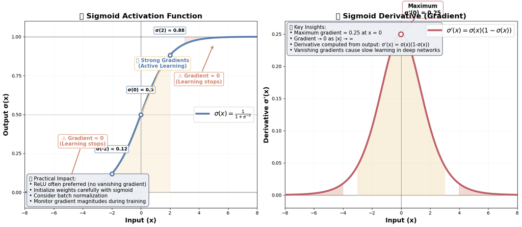

```
📊 Sigmoid Function Analysis:
==================================================
• Maximum gradient: 0.2500 at x = 0
• Gradient at x = ±1: 0.1969
• Gradient at x = ±2: 0.1052
• Gradient at x = ±3: 0.0453

🎯 Backpropagation Implications:
• Strong gradients (-2 < x < 2): Fast learning
• Weak gradients (|x| > 3): Slow/stalled learning
• This is why weight initialization matters!

✨ The Elegant Property:
σ'(x) = σ(x)(1-σ(x))
👉 Derivative computed directly from function output!
👉 No need to recompute exponentials in backprop!
```

```python
# Enhanced visualization of sigmoid function and its derivative
fig, (ax1, ax2) = plt.subplots(1, 2, figsize=(16, 7))

# Generate data with higher resolution
x = np.linspace(-8, 8, 2000)
sigmoid = 1 / (1 + np.exp(-np.clip(x, -500, 500)))  # Clip to avoid overflow
sigmoid_derivative = sigmoid * (1 - sigmoid)

# Enhanced color scheme
sigmoid_color = '#5E81AC'
derivative_color = '#BF616A'
grid_color = '#E5E9F0'
highlight_color = '#EBCB8B'
danger_color = '#D08770'

# Plot sigmoid function with enhanced styling
ax1.plot(x, sigmoid, color=sigmoid_color, linewidth=4,
         label='$\\sigma(x) = \\frac{1}{1+e^{-x}}$', zorder=3)

# Add grid with custom styling
ax1.grid(True, alpha=0.3, color=grid_color, linewidth=1)
ax1.set_axisbelow(True)

# Styling and labels
ax1.set_xlabel('Input (x)', fontsize=14, fontweight='bold')
ax1.set_ylabel('Output σ(x)', fontsize=14, fontweight='bold')
ax1.set_title('🎯 Sigmoid Activation Function', fontsize=16, fontweight='bold')
ax1.legend(fontsize=14, loc='right')

# Reference lines
ax1.axhline(y=0, color='black', linewidth=1, alpha=0.5, zorder=1)
ax1.axhline(y=0.5, color='black', linewidth=1, alpha=0.5, linestyle=':', zorder=1)
ax1.axhline(y=1, color='black', linewidth=1, alpha=0.5, zorder=1)
ax1.axvline(x=0, color='black', linewidth=1, alpha=0.5, zorder=1)

# Set limits and ticks
ax1.set_xlim(-8, 8)
ax1.set_ylim(-0.1, 1.1)
ax1.set_xticks(np.arange(-8, 9, 2))
ax1.set_yticks([0, 0.25, 0.5, 0.75, 1.0])

# Enhanced annotations with better positioning
# Saturation regions
ax1.fill_between(x, 0, sigmoid, where=(x < -3), alpha=0.2, color=danger_color,
                label='Vanishing Gradient Zone')
ax1.fill_between(x, sigmoid, 1, where=(x > 3), alpha=0.2, color=danger_color)

# Active region
ax1.fill_between(x, 0, sigmoid, where=((x >= -2) & (x <= 2)),
                alpha=0.2, color=highlight_color, label='Active Learning Zone')

# Annotate key points
key_points = [(-2, sigmoid[x < -2][-1]), (0, 0.5), (2, sigmoid[x > 2][0])]
point_labels = ['σ(-2) ≈ 0.12', 'σ(0) = 0.5', 'σ(2) ≈ 0.88']

for (px, py), label in zip(key_points, point_labels):
    ax1.plot(px, py, 'o', color='white', markersize=8, markeredgecolor=sigmoid_color,
            markeredgewidth=3, zorder=4)
    ax1.annotate(label, (px, py), xytext=(px, py + 0.15),
                ha='center', fontsize=10, fontweight='bold',
                bbox=dict(boxstyle='round,pad=0.3', facecolor='white',
                         edgecolor=sigmoid_color, alpha=0.9))

# Problem regions annotation
ax1.annotate('⚠️ Gradient ≈ 0\n(Learning stops)',
            xy=(-5, 0.05), xytext=(-4, 0.3),
            arrowprops=dict(arrowstyle='->', color=danger_color, lw=2),
            fontsize=11, ha='center', color=danger_color, fontweight='bold',
            bbox=dict(boxstyle='round,pad=0.3', facecolor='white',
                     edgecolor=danger_color, alpha=0.9))

ax1.annotate('⚠️ Gradient ≈ 0\n(Learning stops)',
            xy=(5, 0.95), xytext=(4, 0.7),
            arrowprops=dict(arrowstyle='->', color=danger_color, lw=2),
            fontsize=11, ha='center', color=danger_color, fontweight='bold',
            bbox=dict(boxstyle='round,pad=0.3', facecolor='white',
                     edgecolor=danger_color, alpha=0.9))

ax1.annotate('✅ Strong Gradients\n(Active Learning)',
            xy=(0, 0.5), xytext=(1.5, 0.8),
            arrowprops=dict(arrowstyle='->', color=highlight_color, lw=2),
            fontsize=11, ha='center', color='#5E81AC', fontweight='bold',
            bbox=dict(boxstyle='round,pad=0.3', facecolor='white',
                     edgecolor=highlight_color, alpha=0.9))

# Plot sigmoid derivative with enhanced styling
ax2.plot(x, sigmoid_derivative, color=derivative_color, linewidth=4,
         label="$\\sigma'(x) = \\sigma(x)(1-\\sigma(x))$", zorder=3)

# Add grid
ax2.grid(True, alpha=0.3, color=grid_color, linewidth=1)
ax2.set_axisbelow(True)

# Styling and labels
ax2.set_xlabel('Input (x)', fontsize=14, fontweight='bold')
ax2.set_ylabel("Derivative σ'(x)", fontsize=14, fontweight='bold')
ax2.set_title("🔥 Sigmoid Derivative (Gradient)", fontsize=16, fontweight='bold')
ax2.legend(fontsize=14, loc='upper right')

# Reference lines
ax2.axhline(y=0, color='black', linewidth=1, alpha=0.5, zorder=1)
ax2.axvline(x=0, color='black', linewidth=1, alpha=0.5, zorder=1)

# Set limits and ticks
ax2.set_xlim(-8, 8)
ax2.set_ylim(-0.02, 0.27)
ax2.set_xticks(np.arange(-8, 9, 2))
ax2.set_yticks([0, 0.05, 0.1, 0.15, 0.2, 0.25])

# Highlight maximum gradient point
max_grad_idx = np.argmax(sigmoid_derivative)
max_x, max_y = x[max_grad_idx], sigmoid_derivative[max_grad_idx]

ax2.plot(max_x, max_y, 'o', color='white', markersize=10,
         markeredgecolor=derivative_color, markeredgewidth=3, zorder=4)
ax2.annotate(f'Maximum\nσ\'(0) = 0.25', (max_x, max_y),
            xytext=(max_x + 1.5, max_y + 0.03),
            arrowprops=dict(arrowstyle='->', color=derivative_color, lw=2),
            fontsize=12, ha='center', fontweight='bold',
            bbox=dict(boxstyle='round,pad=0.4', facecolor='white',
                     edgecolor=derivative_color, alpha=0.9))

# Gradient zones
ax2.fill_between(x, 0, sigmoid_derivative, where=((x >= -3) & (x <= 3)),
                alpha=0.3, color=highlight_color, label='Effective Gradient Zone')
ax2.fill_between(x, 0, sigmoid_derivative, where=((x < -4) | (x > 4)),
                alpha=0.3, color=danger_color, label='Vanishing Gradient Zone')

# Add mathematical insights
insights_text = [
    "💡 Key Insights:",
    "• Maximum gradient = 0.25 at x = 0",
    "• Gradient → 0 as |x| → ∞",
    "• Derivative computed from output: σ'(x) = σ(x)(1-σ(x))",
    "• Vanishing gradients cause slow learning in deep networks"
]

ax2.text(0.02, 0.98, '\n'.join(insights_text), transform=ax2.transAxes,
         fontsize=11, verticalalignment='top',
         bbox=dict(boxstyle='round,pad=0.5', facecolor='#ECEFF4',
                  edgecolor='#4C566A', alpha=0.95))

# Add practical implications
practical_text = [
    "🎯 Practical Impact:",
    "• ReLU often preferred (no vanishing gradient)",
    "• Initialize weights carefully with sigmoid",
    "• Consider batch normalization",
    "• Monitor gradient magnitudes during training"
]

ax1.text(0.02, 0.02, '\n'.join(practical_text), transform=ax1.transAxes,
         fontsize=11, verticalalignment='bottom',
         bbox=dict(boxstyle='round,pad=0.5', facecolor='#ECEFF4',
                  edgecolor='#4C566A', alpha=0.95))

plt.tight_layout()
plt.show()

# Display mathematical relationships
print("📊 Sigmoid Function Analysis:")
print("="*50)
print(f"• Maximum gradient: {np.max(sigmoid_derivative):.4f} at x = 0")
print(f"• Gradient at x = ±1: {sigmoid_derivative[np.abs(x-1).argmin()]:.4f}")
print(f"• Gradient at x = ±2: {sigmoid_derivative[np.abs(x-2).argmin()]:.4f}")
print(f"• Gradient at x = ±3: {sigmoid_derivative[np.abs(x-3).argmin()]:.4f}")
print("\n🎯 Backpropagation Implications:")
print("• Strong gradients (-2 < x < 2): Fast learning")
print("• Weak gradients (|x| > 3): Slow/stalled learning")
print("• This is why weight initialization matters!")

# Show the elegant derivative property
print("\n✨ The Elegant Property:")
print("σ'(x) = σ(x)(1-σ(x))")
print("👉 Derivative computed directly from function output!")
print("👉 No need to recompute exponentials in backprop!")
```

# 💻 Part II: Implementation

*From mathematical equations to working code*

## Modern Framework Templates

Now let's see how backpropagation is implemented in practice using modern deep learning frameworks. Here are the **actual template patterns** you'll use:

### 1. PyTorch Template (Most Common)

```
🔥 PyTorch: Industry Standard Template
========================================
Training PyTorch Model...
Epoch [  0/100] Loss: 1.057988
Epoch [ 20/100] Loss: 1.005641
Epoch [ 40/100] Loss: 0.983772
Epoch [ 60/100] Loss: 0.971879
Epoch [ 80/100] Loss: 0.963561

Test Loss: 0.947691
✅ PyTorch: Automatic differentiation handles all backpropagation!
   → Used by: Tesla, OpenAI, Facebook AI, most research labs
```

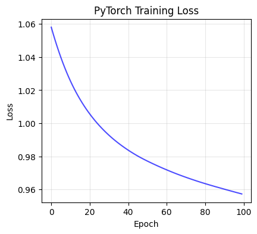

```python
import torch
import torch.nn as nn
import torch.optim as optim
import numpy as np
import matplotlib.pyplot as plt

print("🔥 PyTorch: Industry Standard Template")
print("="*40)

# 1. MODEL DEFINITION (Standard Pattern)
class NeuralNetwork(nn.Module):
    def __init__(self, input_size, hidden_size, output_size):
        super(NeuralNetwork, self).__init__()
        self.network = nn.Sequential(
            nn.Linear(input_size, hidden_size),
            nn.ReLU(),  # Modern activation: ReLU instead of Sigmoid
            nn.Linear(hidden_size, output_size)
        )

    def forward(self, x):
        return self.network(x)

# 2. SETUP (Standard Components)
device = torch.device('cuda' if torch.cuda.is_available() else 'cpu')
model = NeuralNetwork(input_size=10, hidden_size=20, output_size=1).to(device)
criterion = nn.MSELoss()
optimizer = optim.Adam(model.parameters(), lr=0.001)  # Modern optimizer: Adam

# 3. SYNTHETIC DATA (Typical Pattern)
torch.manual_seed(42)
X = torch.randn(1000, 10).to(device)  # 1000 samples, 10 features
y = torch.randn(1000, 1).to(device)   # 1000 targets

# Split data
train_size = int(0.8 * len(X))
X_train, X_test = X[:train_size], X[train_size:]
y_train, y_test = y[:train_size], y[train_size:]

# 4. TRAINING LOOP (Standard Template)
model.train()
train_losses = []
epochs = 100

print("Training PyTorch Model...")
for epoch in range(epochs):
    # Forward pass
    outputs = model(X_train)
    loss = criterion(outputs, y_train)

    # Backward pass (automatic differentiation!)
    optimizer.zero_grad()  # Clear gradients
    loss.backward()        # Compute gradients (backpropagation)
    optimizer.step()       # Update weights

    train_losses.append(loss.item())

    if epoch % 20 == 0:
        print(f"Epoch [{epoch:3d}/{epochs}] Loss: {loss.item():.6f}")

# 5. EVALUATION (Standard Pattern)
model.eval()
with torch.no_grad():
    test_outputs = model(X_test)
    test_loss = criterion(test_outputs, y_test)
    print(f"\nTest Loss: {test_loss.item():.6f}")

print("✅ PyTorch: Automatic differentiation handles all backpropagation!")
print("   → Used by: Tesla, OpenAI, Facebook AI, most research labs")

# Plot training progress
plt.figure(figsize=(10, 4))
plt.subplot(1, 2, 1)
plt.plot(train_losses, color='blue', alpha=0.7)
plt.title('PyTorch Training Loss')
plt.xlabel('Epoch')
plt.ylabel('Loss')
plt.grid(True, alpha=0.3)
```

### 2. Hugging Face Template (NLP/Transformers)

````python
import torch
import torch.nn as nn
import torch.optim as optim
import numpy as np

print("🤗 Hugging Face: Modern NLP & Transformer Template")
print("="*50)

# Simulate Hugging Face-style model architecture
class TransformerStyleModel(nn.Module):
    """
    Demonstrates Hugging Face Transformers patterns:
    - Configuration-based initialization
    - Standardized forward pass with dict outputs
    - Attention mechanisms
    - Easy model saving/loading
    """
    def __init__(self, vocab_size=1000, hidden_size=128, num_classes=2, max_length=10):
        super().__init__()
        self.hidden_size = hidden_size
        self.max_length = max_length

        # HF-style components: embedding -> transformer -> classifier
        self.embedding = nn.Embedding(vocab_size, hidden_size)
        self.positional_encoding = nn.Embedding(max_length, hidden_size)

        # Simplified transformer layer (real HF models use MultiheadAttention)
        self.attention = nn.MultiheadAttention(hidden_size, num_heads=4, batch_first=True)
        self.norm1 = nn.LayerNorm(hidden_size)
        self.norm2 = nn.LayerNorm(hidden_size)

        self.feed_forward = nn.Sequential(
            nn.Linear(hidden_size, hidden_size * 4),
            nn.GELU(),  # HF models typically use GELU
            nn.Dropout(0.1),
            nn.Linear(hidden_size * 4, hidden_size),
            nn.Dropout(0.1)
        )

        self.classifier = nn.Linear(hidden_size, num_classes)

    def forward(self, input_ids, attention_mask=None):
        """HF-style forward pass with named inputs and dict outputs"""
        batch_size, seq_length = input_ids.shape

        # Token embeddings + positional embeddings
        positions = torch.arange(seq_length, device=input_ids.device).unsqueeze(0).expand(batch_size, -1)
        token_embeddings = self.embedding(input_ids)
        position_embeddings = self.positional_encoding(positions)

        embeddings = token_embeddings + position_embeddings

        # Transformer layer with attention
        attn_output, attention_weights = self.attention(embeddings, embeddings, embeddings)
        x = self.norm1(embeddings + attn_output)

        # Feed forward
        ff_output = self.feed_forward(x)
        hidden_states = self.norm2(x + ff_output)

        # Global pooling for classification (mean pooling)
        if attention_mask is not None:
            mask = attention_mask.unsqueeze(-1).float()
            pooled = (hidden_states * mask).sum(dim=1) / mask.sum(dim=1)
        else:
            pooled = hidden_states.mean(dim=1)

        # Classification head
        logits = self.classifier(pooled)

        # HF-style output (dictionary format)
        return {
            "logits": logits,
            "hidden_states": hidden_states,
            "attention_weights": attention_weights
        }

# 1. MODEL SETUP (HF-style with configuration)
print("1. 🏗️  MODEL SETUP (Hugging Face Style)")
print("-" * 35)

config = {
    "vocab_size": 1000,
    "hidden_size": 128,
    "num_classes": 2,
    "max_length": 10
}

model = TransformerStyleModel(**config)
total_params = sum(p.numel() for p in model.parameters())
trainable_params = sum(p.numel() for p in model.parameters() if p.requires_grad)

print(f"✓ Model: TransformerStyleModel")
print(f"✓ Total parameters: {total_params:,}")
print(f"✓ Trainable parameters: {trainable_params:,}")
print(f"✓ Hidden size: {config['hidden_size']}")
print(f"✓ Vocab size: {config['vocab_size']}")

# 2. DATA PREPARATION (HF Tokenizer-style simulation)
print("\n2. 📝 DATA PREPARATION (Tokenized Text Simulation)")
print("-" * 48)

# Simulate tokenized text (in real HF: tokenizer.encode() would do this)
batch_size, seq_length = 16, 10
np.random.seed(42)
torch.manual_seed(42)

# Simulate input_ids (token indices)
input_ids = torch.randint(1, 1000, (batch_size, seq_length))

# Simulate attention_mask (1 for real tokens, 0 for padding)
attention_mask = torch.ones(batch_size, seq_length)
# Add some padding simulation
for i in range(batch_size):
    pad_start = np.random.randint(7, seq_length)
    attention_mask[i, pad_start:] = 0

# Binary classification labels
labels = torch.randint(0, 2, (batch_size,))

print(f"✓ Batch size: {batch_size}")
print(f"✓ Sequence length: {seq_length}")
print(f"✓ Sample input_ids: {input_ids[0].tolist()}")
print(f"✓ Sample attention_mask: {attention_mask[0].tolist()}")
print(f"✓ Sample labels: {labels[:5].tolist()}")

# 3. TRAINING SETUP (HF Trainer-style)
print("\n3. ⚙️  TRAINING SETUP (HF Trainer Style)")
print("-" * 36)

# HF-style loss function and optimizer
criterion = nn.CrossEntropyLoss()
optimizer = optim.AdamW(model.parameters(), lr=2e-5, weight_decay=0.01)  # HF defaults

print("✓ Loss function: CrossEntropyLoss")
print("✓ Optimizer: AdamW (Hugging Face default)")
print("✓ Learning rate: 2e-5 (typical for pre-trained models)")
print("✓ Weight decay: 0.01 (regularization)")

# 4. TRAINING LOOP (Simplified HF Trainer)
print("\n4. 🚀 TRAINING (HF Trainer Simulation)")
print("-" * 35)

model.train()
training_losses = []
epochs = 50

print("Training transformer-style model...")
for epoch in range(epochs):
    # Forward pass with HF-style inputs
    outputs = model(input_ids=input_ids, attention_mask=attention_mask)
    logits = outputs["logits"]

    # Compute loss
    loss = criterion(logits, labels)

    # Backward pass (automatic differentiation)
    optimizer.zero_grad()
    loss.backward()

    # Gradient clipping (common in transformer training)
    torch.nn.utils.clip_grad_norm_(model.parameters(), max_norm=1.0)

    optimizer.step()

    training_losses.append(loss.item())

    if epoch % 10 == 0:
        print(f"Epoch [{epoch:2d}/{epochs}] Loss: {loss.item():.4f}")

# 5. EVALUATION & ANALYSIS
print(f"\n5. 📊 MODEL ANALYSIS")
print("-" * 20)

model.eval()
with torch.no_grad():
    outputs = model(input_ids=input_ids, attention_mask=attention_mask)
    logits = outputs["logits"]
    predictions = torch.argmax(logits, dim=-1)
    accuracy = (predictions == labels).float().mean()

    print(f"✓ Final training loss: {training_losses[-1]:.4f}")
    print(f"✓ Training accuracy: {accuracy:.4f}")
    print(f"✓ Model outputs: {list(outputs.keys())}")
    print(f"✓ Hidden states shape: {outputs['hidden_states'].shape}")
    print(f"✓ Attention weights shape: {outputs['attention_weights'].shape}")

# 6. MODERN FEATURES DEMONSTRATION
print(f"\n6. ✨ MODERN TRANSFORMER FEATURES")
print("-" * 33)

# Show attention visualization concept
attention_weights = outputs['attention_weights'].detach()
print(f"✓ Multi-head attention: {attention_weights.shape[1]} heads")
print(f"✓ Attention matrix: {attention_weights.shape[2:]} per head")

# Show the power of attention mechanism
avg_attention = attention_weights.mean(dim=1)  # Average over heads
print(f"✓ Each token attends to all others (self-attention)")
print(f"✓ Learned relationships automatically via backpropagation")

print("\n🎯 HUGGING FACE ADVANTAGES:")
print("="*35)
print("✅ Pre-trained models (BERT, GPT, RoBERTa)")
print("✅ Automatic tokenization and preprocessing")
print("✅ State-of-the-art architectures out-of-the-box")
print("✅ Easy fine-tuning with Trainer API")
print("✅ Extensive model hub and community")
print("✅ Production-ready inference pipelines")

print("\n📚 REAL HUGGING FACE USAGE:")
print("```python")
print("from transformers import AutoTokenizer, AutoModel")
print("tokenizer = AutoTokenizer.from_pretrained('bert-base-uncased')")
print("model = AutoModel.from_pretrained('bert-base-uncased')")
print("inputs = tokenizer('Hello world!', return_tensors='pt')")
print("outputs = model(**inputs)")
print("```")

print("\n🔥 Used by: Google, Microsoft, Hugging Face, most NLP teams")
````

```
🤗 Hugging Face: Modern NLP & Transformer Template
==================================================
1. 🏗️  MODEL SETUP (Hugging Face Style)
-----------------------------------
✓ Model: TransformerStyleModel
✓ Total parameters: 327,810
✓ Trainable parameters: 327,810
✓ Hidden size: 128
✓ Vocab size: 1000

2. 📝 DATA PREPARATION (Tokenized Text Simulation)
------------------------------------------------
✓ Batch size: 16
✓ Sequence length: 10
✓ Sample input_ids: [790, 618, 251, 50, 64, 435, 413, 942, 716, 867]
✓ Sample attention_mask: [1.0, 1.0, 1.0, 1.0, 1.0, 1.0, 1.0, 1.0, 1.0, 0.0]
✓ Sample labels: [0, 0, 1, 1, 1]

3. ⚙️  TRAINING SETUP (HF Trainer Style)
------------------------------------
✓ Loss function: CrossEntropyLoss
✓ Optimizer: AdamW (Hugging Face default)
✓ Learning rate: 2e-5 (typical for pre-trained models)
✓ Weight decay: 0.01 (regularization)

4. 🚀 TRAINING (HF Trainer Simulation)
-----------------------------------
Training transformer-style model...
Epoch [ 0/50] Loss: 0.7393
Epoch [10/50] Loss: 0.7149
Epoch [20/50] Loss: 0.7021
Epoch [30/50] Loss: 0.6723
Epoch [40/50] Loss: 0.6601

5. 📊 MODEL ANALYSIS
--------------------
✓ Final training loss: 0.6391
✓ Training accuracy: 0.6875
✓ Model outputs: ['logits', 'hidden_states', 'attention_weights']
✓ Hidden states shape: torch.Size([16, 10, 128])
```

[output cut: 50 more lines]

````
✅ State-of-the-art architectures out-of-the-box
✅ Easy fine-tuning with Trainer API
✅ Extensive model hub and community
✅ Production-ready inference pipelines

📚 REAL HUGGING FACE USAGE:
```python
from transformers import AutoTokenizer, AutoModel
tokenizer = AutoTokenizer.from_pretrained('bert-base-uncased')
model = AutoModel.from_pretrained('bert-base-uncased')
inputs = tokenizer('Hello world!', return_tensors='pt')
outputs = model(**inputs)
```

🔥 Used by: Google, Microsoft, Hugging Face, most NLP teams
````

### 3. TensorFlow/Keras Template (Google's Framework)

```
🧠 TensorFlow/Keras: Google's Template
====================================
Model Architecture:
```

```
Model: "sequential_2"
```

```
┏━━━━━━━━━━━━━━━━━━━━━━━━━━━━━━━━━┳━━━━━━━━━━━━━━━━━━━━━━━━┳━━━━━━━━━━━━━━━┓
┃ Layer (type)                    ┃ Output Shape           ┃       Param # ┃
┡━━━━━━━━━━━━━━━━━━━━━━━━━━━━━━━━━╇━━━━━━━━━━━━━━━━━━━━━━━━╇━━━━━━━━━━━━━━━┩
│ dense_6 (Dense)                 │ (None, 64)             │           704 │
├─────────────────────────────────┼────────────────────────┼───────────────┤
│ dropout_2 (Dropout)             │ (None, 64)             │             0 │
├─────────────────────────────────┼────────────────────────┼───────────────┤
│ dense_7 (Dense)                 │ (None, 32)             │         2,080 │
├─────────────────────────────────┼────────────────────────┼───────────────┤
│ dense_8 (Dense)                 │ (None, 1)              │            33 │
└─────────────────────────────────┴────────────────────────┴───────────────┘
```

```
 Total params: 2,817 (11.00 KB)
```

```
 Trainable params: 2,817 (11.00 KB)
```

```
 Non-trainable params: 0 (0.00 B)
```

```
Training TensorFlow Model...
25/25 ━━━━━━━━━━━━━━━━━━━━ 1s 10ms/step - accuracy: 0.4863 - loss: 0.7009 - val_accuracy: 0.4500 - val_loss: 0.6986
25/25 ━━━━━━━━━━━━━━━━━━━━ 1s 10ms/step - accuracy: 0.4863 - loss: 0.7009 - val_accuracy: 0.4500 - val_loss: 0.6986
25/25 ━━━━━━━━━━━━━━━━━━━━ 0s 5ms/step - accuracy: 0.5075 - loss: 0.6948 - val_accuracy: 0.4700 - val_loss: 0.6974
25/25 ━━━━━━━━━━━━━━━━━━━━ 0s 5ms/step - accuracy: 0.5075 - loss: 0.6948 - val_accuracy: 0.4700 - val_loss: 0.6974
25/25 ━━━━━━━━━━━━━━━━━━━━ 0s 5ms/step - accuracy: 0.5450 - loss: 0.6897 - val_accuracy: 0.4550 - val_loss: 0.6975
25/25 ━━━━━━━━━━━━━━━━━━━━ 0s 5ms/step - accuracy: 0.5450 - loss: 0.6897 - val_accuracy: 0.4550 - val_loss: 0.6975
25/25 ━━━━━━━━━━━━━━━━━━━━ 0s 5ms/step - accuracy: 0.5250 - loss: 0.6919 - val_accuracy: 0.4950 - val_loss: 0.6972
25/25 ━━━━━━━━━━━━━━━━━━━━ 0s 5ms/step - accuracy: 0.5250 - loss: 0.6919 - val_accuracy: 0.4950 - val_loss: 0.6972
25/25 ━━━━━━━━━━━━━━━━━━━━ 0s 5ms/step - accuracy: 0.5225 - loss: 0.6902 - val_accuracy: 0.4850 - val_loss: 0.6982
25/25 ━━━━━━━━━━━━━━━━━━━━ 0s 5ms/step - accuracy: 0.5225 - loss: 0.6902 - val_accuracy: 0.4850 - val_loss: 0.6982
25/25 ━━━━━━━━━━━━━━━━━━━━ 0s 5ms/step - accuracy: 0.5337 - loss: 0.6898 - val_accuracy: 0.4650 - val_loss: 0.6996
25/25 ━━━━━━━━━━━━━━━━━━━━ 0s 5ms/step - accuracy: 0.5337 - loss: 0.6898 - val_accuracy: 0.4650 - val_loss: 0.6996
25/25 ━━━━━━━━━━━━━━━━━━━━ 0s 5ms/step - accuracy: 0.5425 - loss: 0.6870 - val_accuracy: 0.4750 - val_loss: 0.6983
25/25 ━━━━━━━━━━━━━━━━━━━━ 0s 5ms/step - accuracy: 0.5425 - loss: 0.6870 - val_accuracy: 0.4750 - val_loss: 0.6983
25/25 ━━━━━━━━━━━━━━━━━━━━ 0s 5ms/step - accuracy: 0.5500 - loss: 0.6858 - val_accuracy: 0.4750 - val_loss: 0.6995
25/25 ━━━━━━━━━━━━━━━━━━━━ 0s 5ms/step - accuracy: 0.5500 - loss: 0.6858 - val_accuracy: 0.4750 - val_loss: 0.6995
25/25 ━━━━━━━━━━━━━━━━━━━━ 0s 5ms/step - accuracy: 0.5387 - loss: 0.6838 - val_accuracy: 0.4600 - val_loss: 0.7009
25/25 ━━━━━━━━━━━━━━━━━━━━ 0s 5ms/step - accuracy: 0.5387 - loss: 0.6838 - val_accuracy: 0.4600 - val_loss: 0.7009
25/25 ━━━━━━━━━━━━━━━━━━━━ 0s 5ms/step - accuracy: 0.5750 - loss: 0.6835 - val_accuracy: 0.4500 - val_loss: 0.7018
25/25 ━━━━━━━━━━━━━━━━━━━━ 0s 5ms/step - accuracy: 0.5750 - loss: 0.6835 - val_accuracy: 0.4500 - val_loss: 0.7018

Test Accuracy: 0.4600
Test Loss: 0.7018
1/1 ━━━━━━━━━━━━━━━━━━━━ 0s 59ms/step

Test Accuracy: 0.4600
Test Loss: 0.7018
1/1 ━━━━━━━━━━━━━━━━━━━━ 0s 59ms/step

First 5 Predictions: [0.5227628  0.5200486  0.5616175  0.52598906 0.50357157]
✅ TensorFlow/Keras: Automatic differentiation + high-level API!
   → Used by: Google, Uber, many production systems
   → Backpropagation handled automatically by .fit() method

First 5 Predictions: [0.5227628  0.5200486  0.5616175  0.52598906 0.50357157]
✅ TensorFlow/Keras: Automatic differentiation + high-level API!
   → Used by: Google, Uber, many production systems
   → Backpropagation handled automatically by .fit() method
```

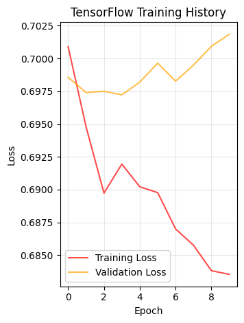

```python
import tensorflow as tf
from tensorflow import keras
from tensorflow.keras import layers
import numpy as np

print("🧠 TensorFlow/Keras: Google's Template")
print("="*36)

# 1. MODEL DEFINITION (Keras Sequential - Most Common)
model = keras.Sequential([
    layers.Dense(64, activation='relu', input_shape=(10,)),
    layers.Dropout(0.2),  # Regularization
    layers.Dense(32, activation='relu'),
    layers.Dense(1, activation='sigmoid')  # Binary classification
])

# 2. COMPILATION (Standard Pattern)
model.compile(
    optimizer='adam',
    loss='binary_crossentropy',
    metrics=['accuracy']
)

# 3. DATA PREPARATION
np.random.seed(42)
X_train = np.random.random((1000, 10))
y_train = np.random.randint(2, size=(1000, 1))
X_test = np.random.random((200, 10))
y_test = np.random.randint(2, size=(200, 1))

print("Model Architecture:")
model.summary()

# 4. TRAINING (One Line!)
print("\nTraining TensorFlow Model...")
history = model.fit(
    X_train, y_train,
    batch_size=32,
    epochs=10,
    validation_split=0.2,
    verbose=1
)

# 5. EVALUATION
test_loss, test_accuracy = model.evaluate(X_test, y_test, verbose=0)
print(f"\nTest Accuracy: {test_accuracy:.4f}")
print(f"Test Loss: {test_loss:.4f}")

# 6. PREDICTION
predictions = model.predict(X_test[:5])
print(f"\nFirst 5 Predictions: {predictions.flatten()}")

print("✅ TensorFlow/Keras: Automatic differentiation + high-level API!")
print("   → Used by: Google, Uber, many production systems")
print("   → Backpropagation handled automatically by .fit() method")

# Plot training history
plt.subplot(1, 2, 2)
plt.plot(history.history['loss'], label='Training Loss', color='red', alpha=0.7)
plt.plot(history.history['val_loss'], label='Validation Loss', color='orange', alpha=0.7)
plt.title('TensorFlow Training History')
plt.xlabel('Epoch')
plt.ylabel('Loss')
plt.legend()
plt.grid(True, alpha=0.3)

plt.tight_layout()
plt.show()
```

## 🎯 Framework Selection Guide

| Framework | **Best For** | **Key Strengths** | **Backprop Method** |
| --- | --- | --- | --- |
| **PyTorch** | Research & Learning | Direct control, dynamic graphs, debugging | `loss.backward()` |
| **Hugging Face** | NLP & Pre-trained Models | Model hub, fine-tuning, transformers | `trainer.train()` |
| **TensorFlow** | Production & Deployment | Industry standard, scalability, serving | `model.fit()` |

## 💡 Key Insights for Students

### **Same Math, Different APIs**

All three frameworks implement **identical backpropagation mathematics**:

- Same chain rule application
- Same gradient computations
- Same weight updates
- **Different syntax, same results**

### **Modern Development Reality**

1. **You don't implement backpropagation from scratch** - frameworks handle it
2. **Focus on**: Architecture design, data preparation, hyperparameter tuning
3. **Master one framework deeply**, understand others conceptually
4. **All roads lead to the same destination** - working neural networks!